# Gender pay gap analysis of all academic staff at a US university

Manish Kukreja

25 May 2016

# Problem Statement

Given the salaries for all academic staff at a US university. We are interested in whether gender has a direct effect on salary, which would be unlawful discrimination.

# Data Description

The `salary.txt` file contains salaries for all academic staff at a US university. It is part of a file made public in a gender discrimination lawsuit. The variables are:

- `gender`: M or F
- `deg`: highest degree is PhD or Other
- `yrdeg`: year of highest degree
- `field`: Visual and Performing Arts vs Professional (Medicine, Law, Nursing, etc) vs Other
- `startyr`: first year of employment at this institution
- `year`: year of most recent salary data for this person
- `rank`: Assistant Professor (Lecturer, Associate Professor (Senior Lecturer), Full Professor (A/Prof, Prof)
- `admin`: has extra pay for administrative/managerial responsibility (Deans, etc)
- `salary`: Monthly salary

# Game Plan

A. Explore causality  
B. Guess the missing variables  
C. Fit the model  
D. Analyse the results  
E. Provide executive summary

## A. Explore causality

To study the direct effect (causality) let us first draw the causal graph with all the variables given in the dataset.

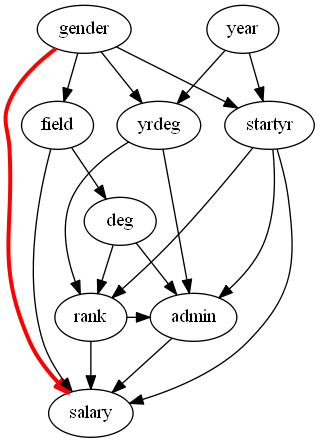

Based on the given dataset, `gender` would have an impact on choosing a `field`, completion of highest degree (`yrdeg`) and starting to work at that institution (`startyr`). Similarly, a `field` would determine whether highest degree would be PhD or other (`deg`). Using `year` & `yrdeg` overall experience can be calculated and `year` & `startyr` would give experience at that institute. Overall experience and institutional experience would have an effect on `rank` and `admin` variables. Also, `deg` would have impact on `rank` and `admin` variables. Variables such as `rank`, `admin` and `field` would have an impact on salary. Red edge between `gender` and `salary` represents the relationship of our interest.

## B. Missing variables

We think, some important variables not in the dataset that vital for this causal question are:

1. `family` - this variable could provide information whether the staff has any family responsibilities or not such as childcare or sick person care at home, this could impact the number of hours and/or workload of the staff. Usually females have childcare responsibilities that can result in stronger preferences in certain shift timings, place of work, etc.
2. `courses` - this variable could provide information about number of courses a staff is responsible for. More courses indicates more salary. Only certain ranks could be eligible for teaching/co-ordinating more courses.
3. `grantfunds` - this variable provides information about research grant funds or external sponsorship. Certain fields could have research grant funds at departmental level, that allows staff to earn extra salary for e.g. summer research. Since choosing a field depends upon individual preferences therefore this component could be missed by some staff if their departments do not have such funds.

Let us see how these missing variables can affect the casuality.

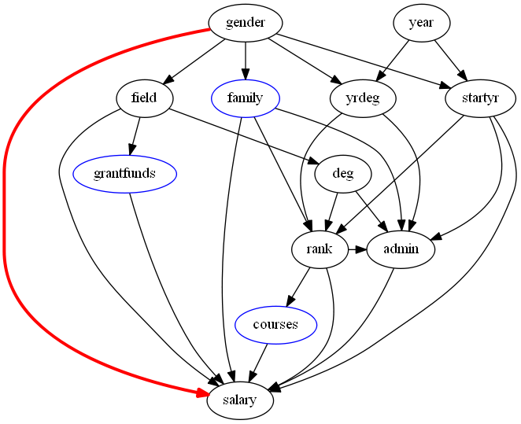

## C. Fit the model

Since we do not have information about these missing variables, we are restricting just to the variables in the dataset and pretending that no other variables are needed, estimate the overall effect and direct effect of gender on salary (this may depend, e.g., on year).

```r
salary.df=read.table("salary.txt",header= T)
summary(salary.df)
```

```
##  gender      deg           yrdeg         field         startyr
##  F: 408   Other: 142   Min.   :48.00   Arts : 220   Min.   :48.0
##  M:1187   PhD  :1350   1st Qu.:69.00   Other:1065   1st Qu.:73.0
##           Prof : 103   Median :75.00   Prof : 310   Median :83.0
##                        Mean   :76.08                Mean   :81.1
##                        3rd Qu.:84.00                3rd Qu.:90.0
##                        Max.   :96.00                Max.   :95.0
##
##       year        rank         admin           salary
##  Min.   :95   Assist:313   Min.   :0.000   Min.   : 3042
##  1st Qu.:95   Assoc :437   1st Qu.:0.000   1st Qu.: 4743
##  Median :95   Full  :845   Median :0.000   Median : 5962
##  Mean   :95                Mean   :0.106   Mean   : 6392
##  3rd Qu.:95                3rd Qu.:0.000   3rd Qu.: 7602
##  Max.   :95                Max.   :1.000   Max.   :14464
##                                            NA's   :1
```

```r
# Remove NA's (handle missing data)
salary.df.na.rm=na.omit(salary.df)
summary(salary.df.na.rm)
```

```
##  gender      deg           yrdeg         field         startyr
##  F: 408   Other: 142   Min.   :48.00   Arts : 220   Min.   :48.00
##  M:1186   PhD  :1349   1st Qu.:69.00   Other:1064   1st Qu.:73.00
##           Prof : 103   Median :75.00   Prof : 310   Median :83.00
##                        Mean   :76.06                Mean   :81.09
##                        3rd Qu.:84.00                3rd Qu.:90.00
##                        Max.   :95.00                Max.   :95.00
##       year        rank         admin           salary
##  Min.   :95   Assist:312   Min.   :0.000   Min.   : 3042
##  1st Qu.:95   Assoc :437   1st Qu.:0.000   1st Qu.: 4743
##  Median :95   Full  :845   Median :0.000   Median : 5962
##  Mean   :95                Mean   :0.106   Mean   : 6392
##  3rd Qu.:95                3rd Qu.:0.000   3rd Qu.: 7602
##  Max.   :95                Max.   :1.000   Max.   :14464
```

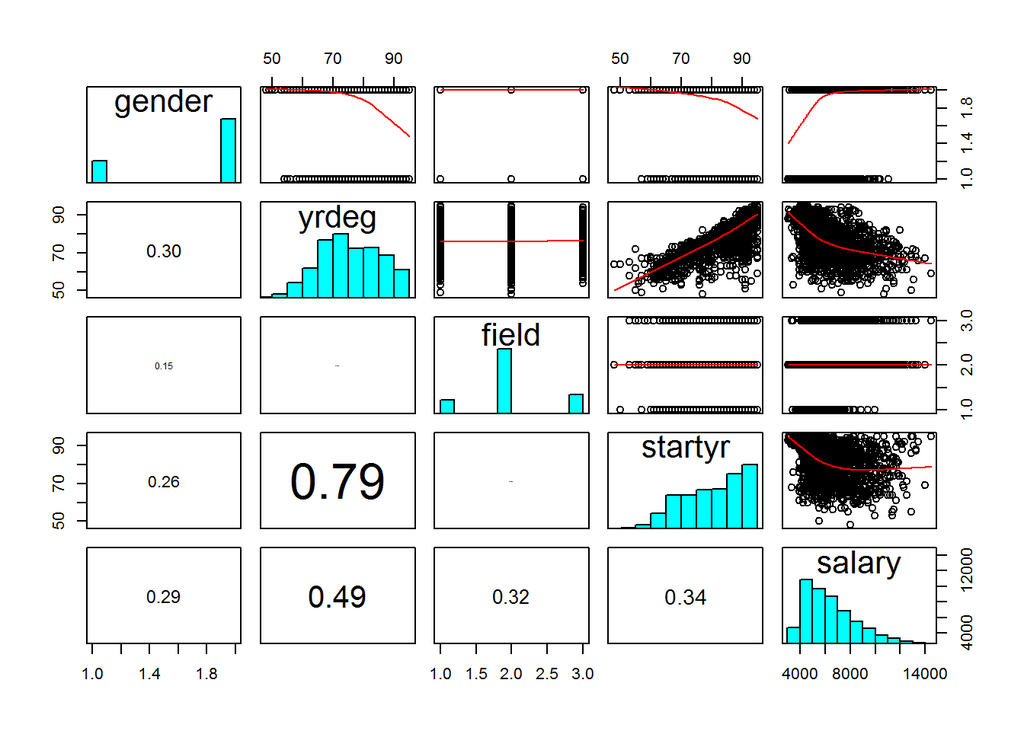

```r
pairs20x(salary.df.na.rm[c(1,3,4,5,9)])
```

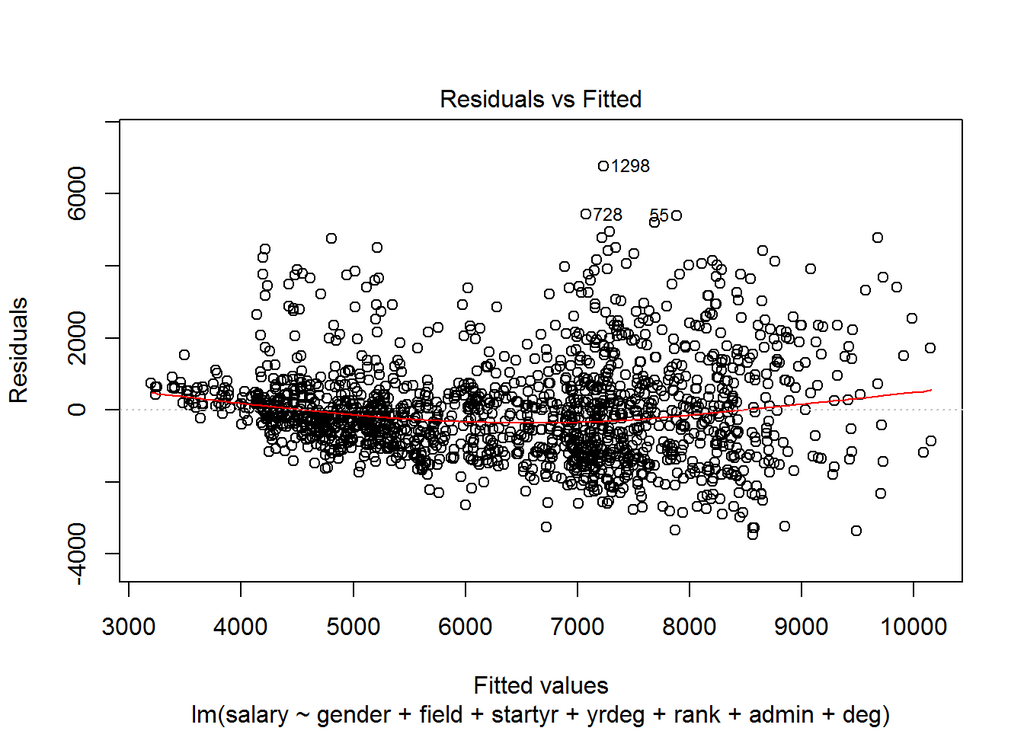

```r
# no unusual points seen, lets model it

salary.lm=lm(salary~gender+field+startyr+yrdeg+rank+admin+deg,data=salary.df.na.rm )

plot(salary.lm, which =1)
```

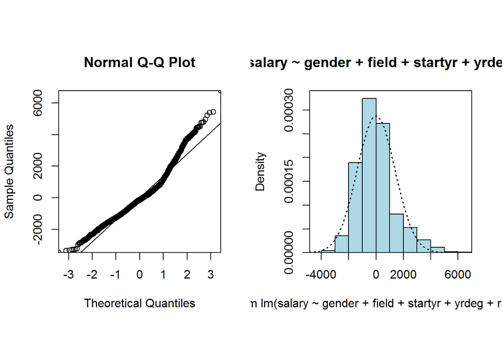

```r
# EOV check is not pass, as residuals are not evenly spread

normcheck(salary.lm)
```

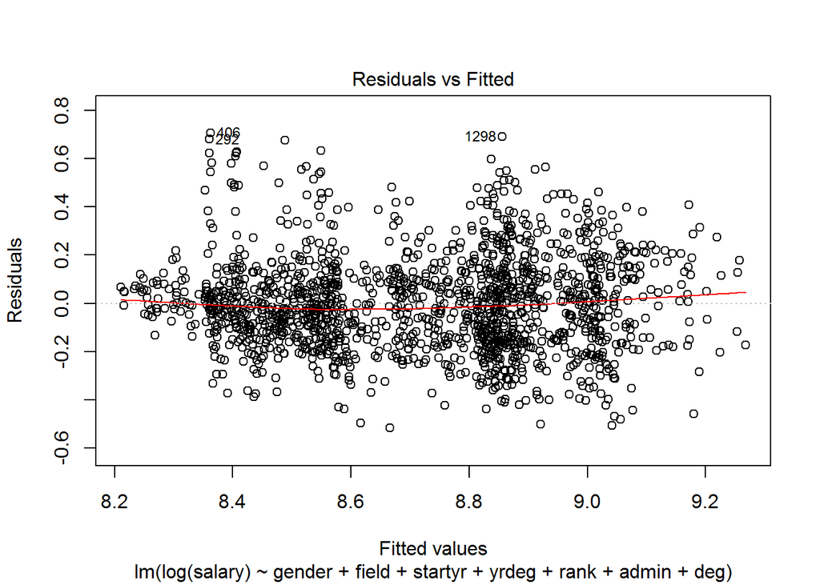

```r
# QQ plot shows right skewness

# Let's log the response
salary.lm2=lm(log(salary)~gender+field+startyr+yrdeg+rank+admin+deg,data=salary.df.na.rm )

plot(salary.lm2, which =1)
```

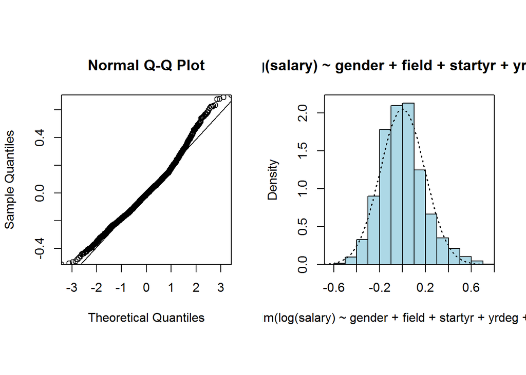

```r
# EOV check is passed

normcheck(salary.lm2)
```

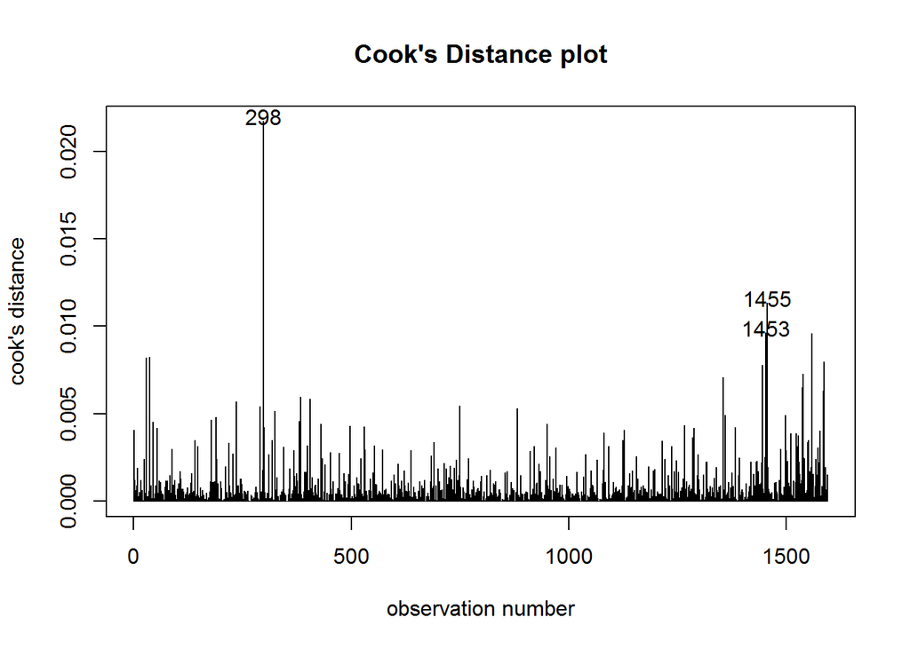

```r
# QQ plot looks normal

cooks20x(salary.lm2)
```

```r
# No unduly influential points

summary(salary.lm2)
```

```
##
## Call:
## lm(formula = log(salary) ~ gender + field + startyr + yrdeg +
##     rank + admin + deg, data = salary.df.na.rm)
##
## Residuals:
##     Min      1Q  Median      3Q     Max
## -0.5175 -0.1357 -0.0110  0.1087  0.7055
##
## Coefficients:
##               Estimate Std. Error t value Pr(>|t|)
## (Intercept)  8.4238003  0.0690913 121.923  < 2e-16 ***
## genderM      0.0468734  0.0119951   3.908 9.71e-05 ***
## fieldOther   0.1006019  0.0150351   6.691 3.06e-11 ***
## fieldProf    0.2527157  0.0181729  13.906  < 2e-16 ***
## startyr      0.0042225  0.0008252   5.117 3.48e-07 ***
## yrdeg       -0.0067515  0.0009486  -7.117 1.66e-12 ***
## rankAssoc    0.1021684  0.0160144   6.380 2.32e-10 ***
## rankFull     0.3770154  0.0184083  20.481  < 2e-16 ***
## admin        0.1618027  0.0162263   9.972  < 2e-16 ***
## degPhD       0.0685395  0.0184465   3.716  0.00021 ***
## degProf      0.1367500  0.0262331   5.213 2.10e-07 ***
## ---
## Signif. codes:  0 '***' 0.001 '**' 0.01 '*' 0.05 '.' 0.1 ' ' 1
##
## Residual standard error: 0.1951 on 1583 degrees of freedom
## Multiple R-squared:  0.5884, Adjusted R-squared:  0.5858
## F-statistic: 226.3 on 10 and 1583 DF,  p-value: < 2.2e-16
```

```r
exp(confint(salary.lm2))
```

```
##                    2.5 %      97.5 %
## (Intercept) 3976.9886132 5215.136264
## genderM        1.0236201    1.072939
## fieldOther     1.0737005    1.138934
## fieldProf      1.2424313    1.334239
## startyr        1.0026074    1.005858
## yrdeg          0.9914248    0.995121
## rankAssoc      1.0733201    1.142913
## rankFull       1.4062240    1.511530
## admin          1.1388003    1.213647
## degPhD         1.0328865    1.110402
## degProf        1.0890381    1.207081
```

```r
# salary.lm2 model gives us direct effect of gender on salary

# lets calculate total effect of gender on salary
salary.lm3=lm(log(salary)~gender,data=salary.df.na.rm )
summary(salary.lm3)
```

```
##
## Call:
## lm(formula = log(salary) ~ gender, data = salary.df.na.rm)
##
## Residuals:
##      Min       1Q   Median       3Q      Max
## -0.72033 -0.21346 -0.02534  0.19829  0.81011
##
## Coefficients:
##             Estimate Std. Error t value Pr(>|t|)
## (Intercept)  8.55989    0.01431  598.17   <2e-16 ***
## genderM      0.20942    0.01659   12.62   <2e-16 ***
## ---
## Signif. codes:  0 '***' 0.001 '**' 0.01 '*' 0.05 '.' 0.1 ' ' 1
##
## Residual standard error: 0.2891 on 1592 degrees of freedom
## Multiple R-squared:  0.09099,    Adjusted R-squared:  0.09042
## F-statistic: 159.4 on 1 and 1592 DF,  p-value: < 2.2e-16
```

```r
exp(confint(salary.lm3))
```

```
##                   2.5 %      97.5 %
## (Intercept) 5073.661354 5366.629739
## genderM        1.193492    1.273749
```

## D. Analysis of the fitted model

Direct effect of gender on salary, salary of males is between 0.02 and 0.07 times more than females.

Overall effect of gender on salary, salary of males is between 0.19 and 0.27 times more than females.

## E. Executive Summary

Given data does take into consideration about field of work, education and experience, however there could be other important factors such as family responsibilities, number of courses taught, summer research that also needs to be considered before drawing conclusions about discrimination.